# Goncalves Modelling (Model Selection via Maximum Likelihood)

Florian Bach

25/02/2022

## Hypotheses

To further characterise the the best model to describe the risk dynamics of severe disease we will use maximum likelihood estimation and AIC to test several models:

1. The risk of severe disease is constant across infections
2. The risk of severe disease declines at a constant rate with the number of infections.
3. The risk of severe disease drops sharply from 1st to 2nd infection in life and then declines at a constant rate.
4. The risk of severe disease declines exponentially.

As a reminder, here are the fractions we’re modelling.

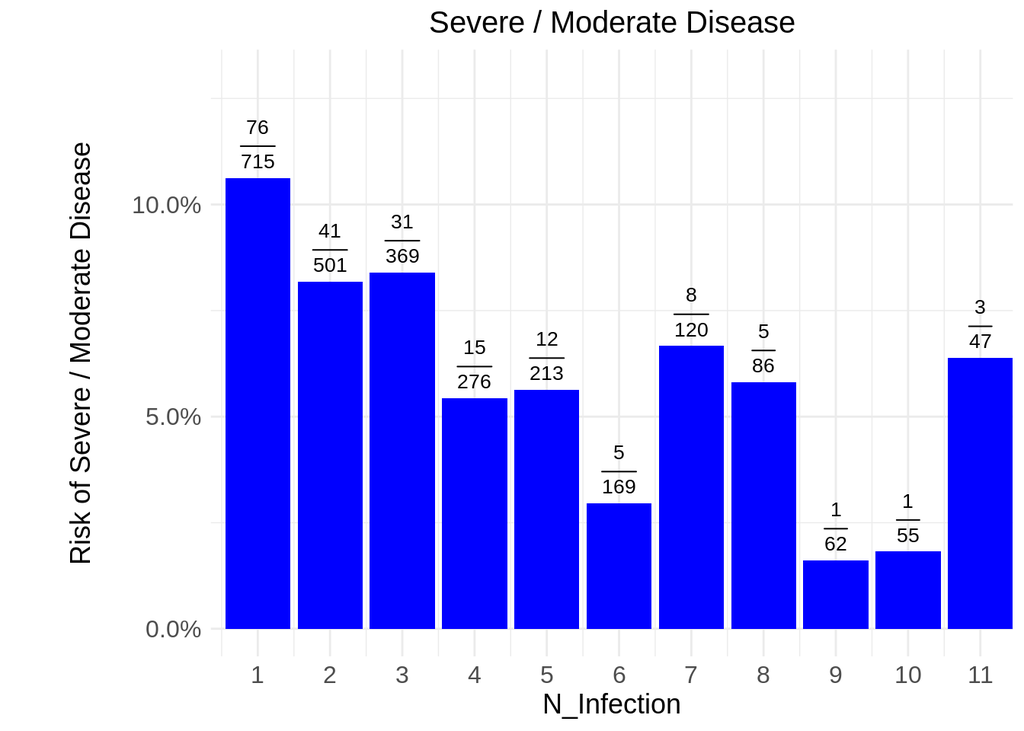

## Model Definitions

We will model the data as derived from a binomial distribution $N \sim {\sf Binom}(M, P_{i})$ where

- $N$ is a vector of successes (i.e. instances of severe disease at each order of infection $i$)
- $M$ is a vector of the number of observations (i.e. number infections at each order of infection $i$)
- $P_{i}$ is a vector of probabilities giving the probability $p$ of success at each trial (i.e. the severe disease risk at each order of infection $i$)

The first two parameters $N, M$ are fixed, as they correspond to the numerator and denominator of the fractions of severe disease, respectively, at each order of infection. The vector of probabilities of success, $P_{i}$, is what we aim to estimate using maximum likelihood. In this format the above hypotheses 1-4) can be rewritten as estimating $P_{i}$ as:

1. $P_{i} = p_{1} =$ constant
2. $P_{i} = p_{1}-\alpha(i-1)$
3. $P_{i} = p_{1} -\alpha(i-2)$
4. $P_{i} = p_{1} e^{-\alpha(i-1)}$

For determining the maximum likelihood I used `stats4::mle()` which implements the Nelder-Mead algorithm (https://doi.org/10.1093/comjnl/7.4.308).

Model Comparison

| Model | P1 | SE(P1) | alpha | SE(alpha) | logL | AIC |
| --- | --- | --- | --- | --- | --- | --- |
| No Decay | 0.0757752 | 0.0051762 | NA | 0.0051762 | -35.48514 | 72.97027 |
| Constant Decay | 0.0928542 | 0.0066130 | 0.0068751 | 0.0011272 | -27.02978 | 58.05955 |
| Constant Decay with Kink | 0.0863059 | 0.0060170 | 0.0069997 | 0.0011927 | -27.02426 | 58.04851 |
| Exponential Decay | 0.1006839 | 0.0089271 | 0.1344263 | 0.0328437 | -25.71021 | 55.42042 |
| Exponential Decay (glm) | 0.1285667 | 0.1230470 | 0.1432331 | 0.0348684 | -25.76868 | 55.53736 |

I tried different versions of the kink model ($i-3$ etc.), but none of them did well. I also tried a model with a third parameter $p_{1} -\alpha(i-j)$ to model ideal position of the kink, but ran into a problem of local minima, where the estimate for j was always very close to the starting position of the optimiser.

Based on AIC & log likelihood, exponential decay provides the best fit for this data. The corresponding model is shown below on the left, next to the logistic regression model suggested by `stats::glm()`. I am not 100% sure why those two models are slightly different, and particularly why the confidence interval on the logistic regression model is that much tighter, but I’m trying to read up on the underlying methods.

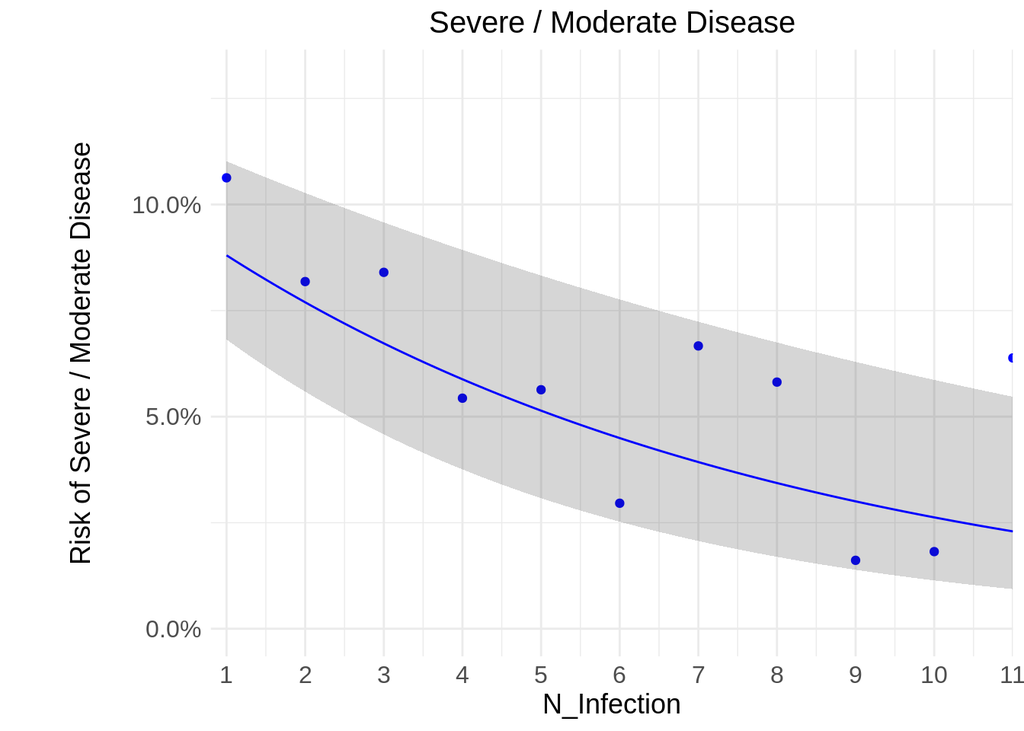

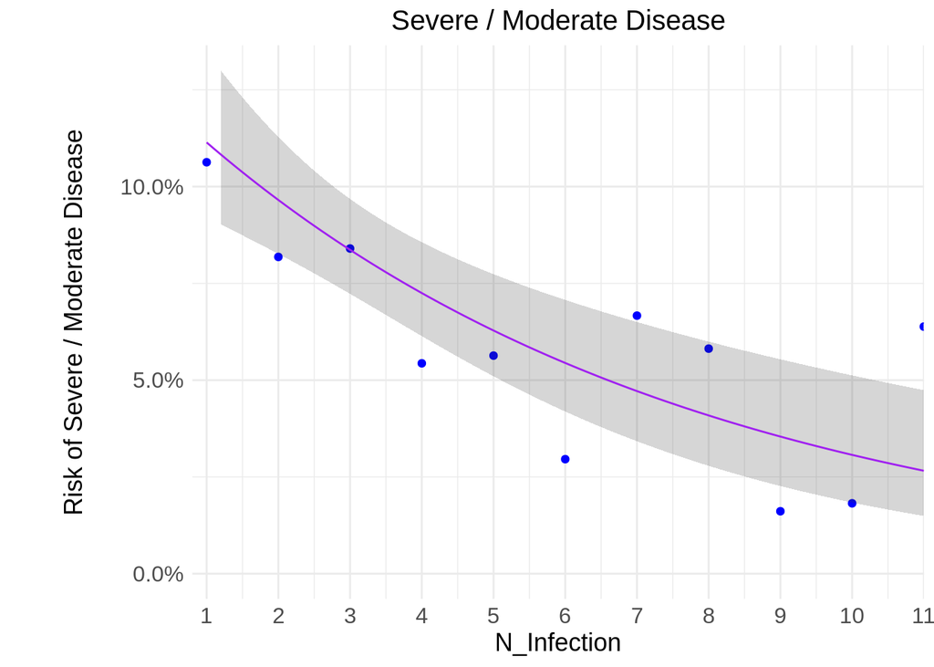